# Patterns in the Juan Fernandez fur seal faecal microbiome: R script 3

Constanza Toro

This is script number 3 of a series of html files containing all the code used for the statistical analysis of "Patterns in the Juan Fernandez fur seal (Arctophoca philippii philippii) faecal microbiome". The direct outputs of this analysis were the object generated with Script 1 located in the R_code folder within this [GitHub repository](https://github.com/Cotissima/JFFS_microbiome_first_characterisation). This script aims to look at betadiversity, correlations and genus abundance difference.

This script includes the following sections:  
*Note: files needed to run this coded were generated in section 4 of Script 1*  
1. Betadiversity  
1.1. Principal coordinate analysis (PCoA)  
1.1.1. Bray curtis  
1.1.1.1. Full data  
1.1.1.2. Core data  
1.1.2. Weighted Unifrac  
1.1.2.1. Full data  
1.1.2.2. Core data  
1.2. Clusters exploration 1.3. Hypothesis testing 5. Similarity Percentages analysis (SIMPER) 6. Correlation Analysis

- Load libraries

```r
library(tidyverse)
library(vegan)
library(ape)
library(kableExtra)
```

- Load metadata  
  *Note: using rarefied data*

```r
# Full meta
read.csv("F2meta.csv") -> JFFS.meta
# Full rarefied ASV matrix
read.csv("ASV.RF.csv",
         row.names = 1,
         check.names = FALSE) -> ASV.RF

# Core meta
read.csv("F2coremeta.csv") -> core.meta
# Core rarefied ASV matrix
read.csv("ASV.RC.csv",
         row.names = 1,
         check.names = FALSE) -> ASV.RC
```

# 1. Betadiversity analysis

Beta-diversity is the rate of change in species composition from one community to another along gradients. Rarefied full and core data will be used.

## 1.1 Principal coordinate analysis (exploratory)

### 1.1.1 Bray curtis

#### 1.1.1.1 Full rarefied dataset

- Calculate a Bray-Curtis matrix and run PCoA

```r
# Calculate a  Bray-Curtis distance matrix. Note that vegan requires n x m matrix of n samples and m variables.
vegdist(ASV.RF,
        method = "bray") -> dist_RF

pcoa(dist_RF) -> PCoA_RF
```

**Figure 1:** Eigen values plot

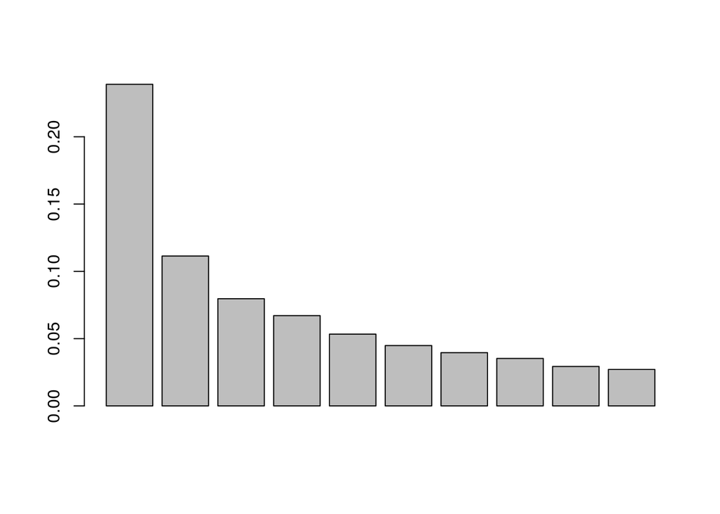

```r
barplot(PCoA_RF$values$Relative_eig[1:10])
```

About 35% of the variation is explained by the first two principal components.

**Figure 2:** PCoA using Bray-Curtis dissimilarity distance matrix

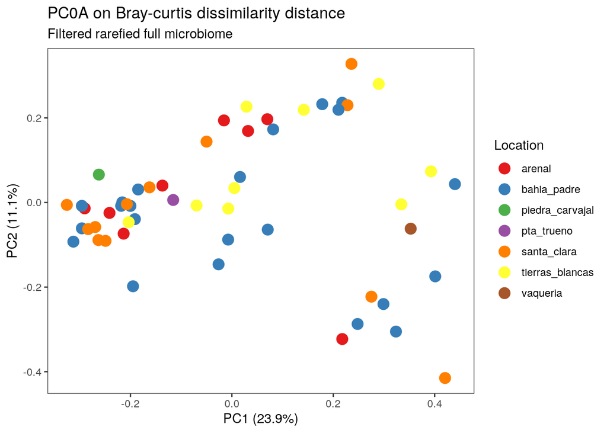

```r
# Extract the first 2 PCs
PCOAaxes <- PCoA_RF$vectors[,c(1,2)]
colnames(PCOAaxes) = c("AxisBC_1", "AxisBC_2")

# Add to metadata
cbind(JFFS.meta, PCOAaxes) -> JFFS.meta

#plot
ggplot(JFFS.meta,
       aes(AxisBC_1,
           AxisBC_2,
           color = Location,
           fill = Location)) +
  geom_point(size = 4) +
  scale_fill_brewer(palette = "Set1") +
  scale_colour_brewer(palette = "Set1") +
  theme_bw() +
  xlab("PC1 (23.9%)") +
  ylab("PC2 (11.1%)") +
  labs(title = "PC0A on Bray-curtis dissimilarity distance",
       subtitle = "Filtered rarefied full microbiome") +
  theme(panel.grid.major = element_blank(),
        panel.grid.minor = element_blank())
```

Bray Curtis quantifies the compositional dissimilarity between groups. Samples do not cluster based on location. However, it is possible to differentiate two clusters (top-left and bottom right). For the final image, a new cluster label will be added.

**Figure 3:** PCoA using Bray-Curtis dissimilarity distance matrix (with cluster) *In manuscript: Supplementary figure 3*

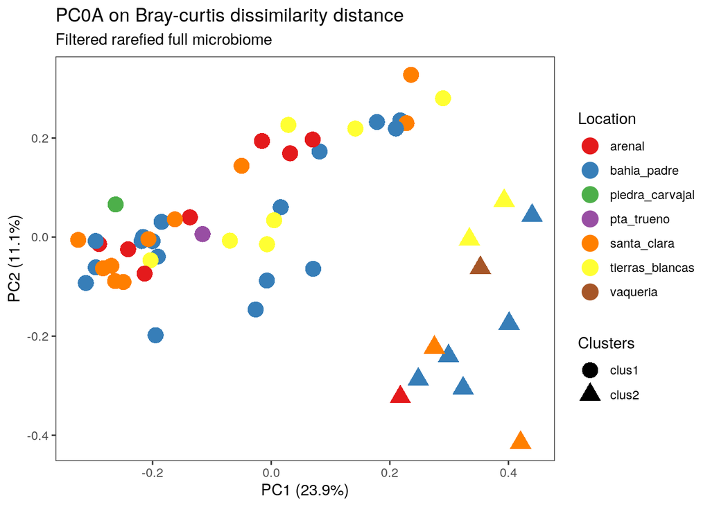

```r
# Create a variable group base on BC clustering
clus2 <- c("17JFFS19", "17JFFS1", "17JFFS25", "17JFFS24", "17JFFS5", "17JFFS4", "17JFFS11", "18JFFS4", "18JFFS21", "18JFFS9", "18JFFS23")

# add to metadata
JFFS.meta$BC_clus <- ifelse(JFFS.meta$label %in% clus2,
                           "clus2",
                           "clus1")

#plot
ggplot(JFFS.meta,
       aes(AxisBC_1,
           AxisBC_2,
           color = Location,
           shape = BC_clus)) +
  geom_point(size = 5,
             alpha = 1) +
  scale_colour_brewer(palette = "Set1") +
  theme_bw() +
  xlab("PC1 (23.9%)") +
  ylab("PC2 (11.1%)") +
  labs(title = "PC0A on Bray-curtis dissimilarity distance",
       subtitle = "Filtered rarefied full microbiome",
       shape = "Clusters") +
  theme(panel.grid.major = element_blank(),
        panel.grid.minor = element_blank())
```

#### 1.1.1.2 Rarefied core dataset

- Calculate a Bray-Curtis matrix and run PCoA

```r
# Calculate a  Bray-Curtis distance matrix. Note that vegan requires n x m matrix of n samples and m variables.
vegdist(ASV.RC,
        method = "bray") -> dist_RC

pcoa(dist_RC) -> PCoA_RC
```

**Figure 4:** Eigen values plot

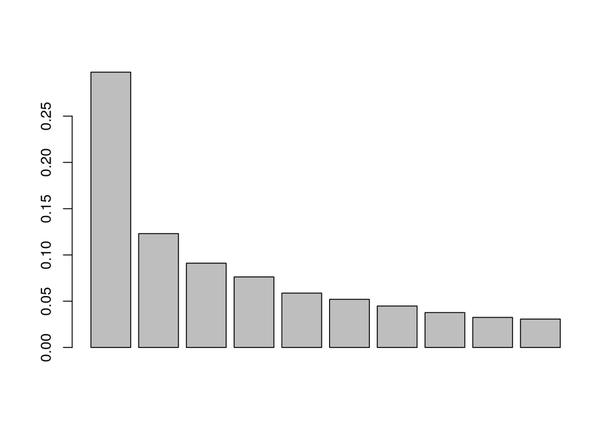

```r
barplot(PCoA_RC$values$Relative_eig[1:10])
```

About 42% of the variation is explained by the first two principal components.

**Figure 5:** PCoA using Bray-Curtis dissimilarity distance matrix. Core data

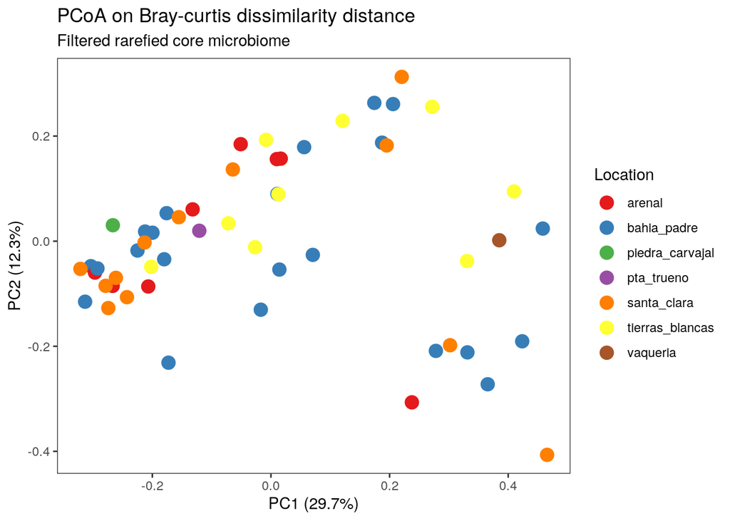

```r
# Extract the first 2 PCs
PCOAaxes <- PCoA_RC$vectors[,c(1,2)]
colnames(PCOAaxes) = c("AxisBC_1", "AxisBC_2")

# Add to metadata
cbind(core.meta, PCOAaxes) -> core.meta

#plot
ggplot(core.meta,
       aes(AxisBC_1,
           AxisBC_2,
           color = Location,
           fill = Location)) +
  geom_point(size = 4) +
  scale_fill_brewer(palette = "Set1") +
  scale_colour_brewer(palette = "Set1") +
  theme_bw() +
  xlab("PC1 (29.7%)") +
  ylab("PC2 (12.3%)") +
  labs(title = "PCoA on Bray-curtis dissimilarity distance",
       subtitle = "Filtered rarefied core microbiome") +
  theme(panel.grid.major = element_blank(),
        panel.grid.minor = element_blank())
```

When using the core data set, a similar and slightly stronger signal can be identified. As before, the final plot will be constructed using the a new cluster variable.

** Figure 6:** PCoA using Bray-Curtis dissimilarity distance matrix using the core dataset (with cluster) *In manuscript: Figure 3*

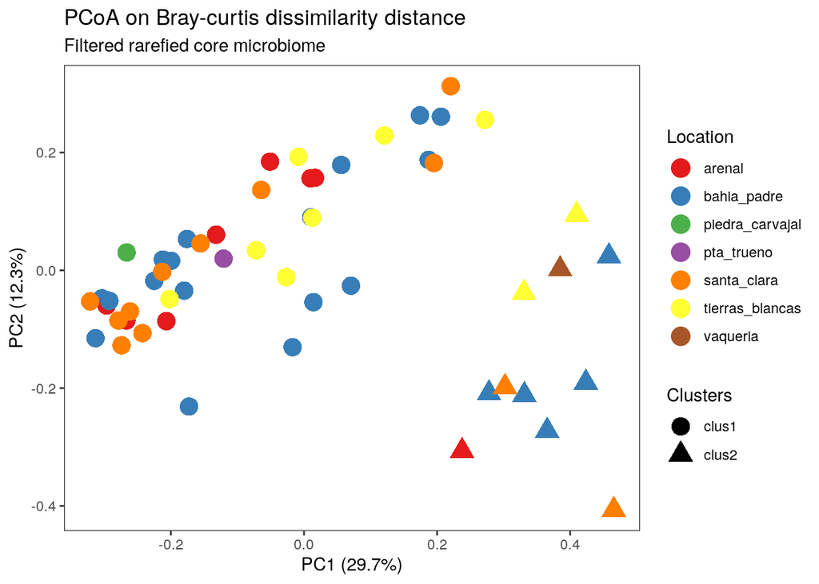

```r
# add to metadata (using the same clus2 vector created earlier)
core.meta$BC_clus <- ifelse(core.meta$label %in% clus2,
                           "clus2",
                           "clus1")

#plot
ggplot(core.meta,
       aes(AxisBC_1,
           AxisBC_2,
           color = Location,
           shape = BC_clus)) +
  geom_point(size = 5,
             alpha = 1) +
  scale_colour_brewer(palette = "Set1") +
  theme_bw() +
  xlab("PC1 (29.7%)") +
  ylab("PC2 (12.3%)") +
  labs(title = "PCoA on Bray-curtis dissimilarity distance",
       subtitle = "Filtered rarefied core microbiome",
       shape = "Clusters") +
  theme(panel.grid.major = element_blank(),
        panel.grid.minor = element_blank())
```

### 1.1.2 Weighted unifrac

- Load newick trees

```r
# Filtered full dataset
read.tree("FRTree.tree") -> FRTree

# Filtered core dataset
read.tree("CRTree.tree") -> CRTree
```

#### 1.1.2.1 Full rarefied dataset

- Calculate a Weighted unifrac matrix and run PCoA

```r
library(rbiom)
# Calculate a  unifrac distance matrix. Note that rbiom requires n x m matrix of n variable and m samples.
unifrac(t(ASV.RF),
        weighted = TRUE,
        tree = FRTree) -> RFuni


pcoa(RFuni) -> PCoA_RF
```

**Figure 7:** Eigen values plot

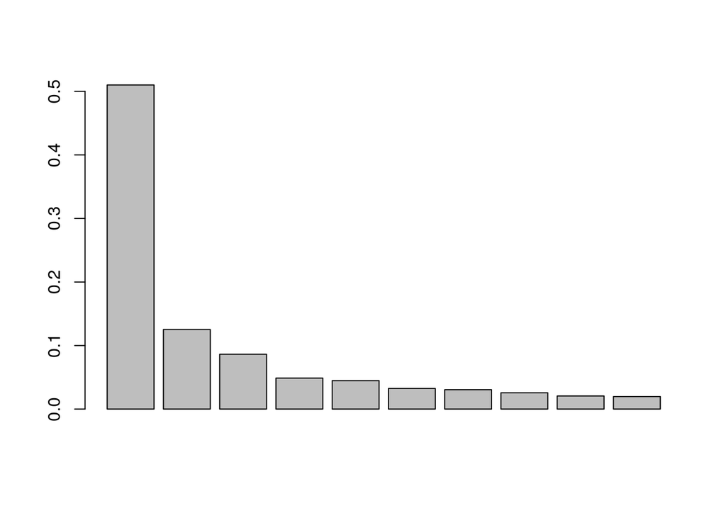

```r
barplot(PCoA_RF$values$Relative_eig[1:10])
```

About 63% of the variation is explained by the first two principal components.

**Figure 8:** PCoA using weighted unifrac distance matrix.  
*Note. we expected a similar clustering pattern*

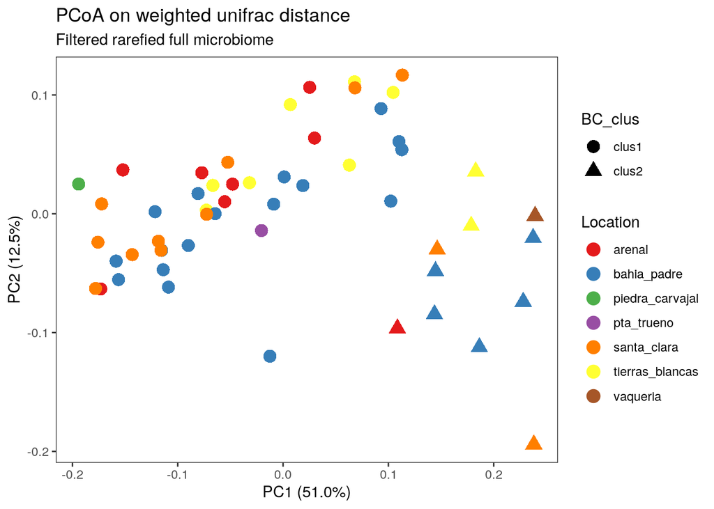

```r
# Extract the first 2 PCs
PCOAaxes <- PCoA_RF$vectors[,c(1,2)]
colnames(PCOAaxes) = c("AxisWU_1", "AxisWU_2")

# Add to metadata
cbind(JFFS.meta, PCOAaxes) -> JFFS.meta

#plot
ggplot(JFFS.meta,
       aes(AxisWU_1,
           AxisWU_2,
           color = Location,
           fill = Location,
           shape = BC_clus)) +
  geom_point(size = 4) +
  scale_colour_brewer(palette = "Set1") +
  theme_bw() +
  xlab("PC1 (51.0%)") +
  ylab("PC2 (12.5%)") +
  labs(title = "PCoA on weighted unifrac distance",
       subtitle = "Filtered rarefied full microbiome") +
  theme(panel.grid.major = element_blank(),
        panel.grid.minor = element_blank())
```

A similar pattern was observed when using a weighted unifraq distance.

#### 1.1.2.2 Rarefied core dataset

- Calculate a weighted unifrac matrix and run PCoA

```r
# Calculate a  weighted unifrac distance matrix. Note that rbiom requires n x m matrix of n samples and m variables.
unifrac(t(ASV.RC),
        weighted = TRUE,
        tree = FRTree) -> RCuni

pcoa(RCuni) -> PCoA_RC
```

**Figure 9:** Eigen values plot

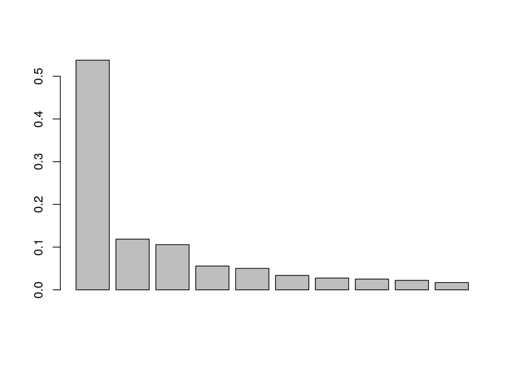

```r
barplot(PCoA_RC$values$Relative_eig[1:10])
```

About 65.7% of the variation is explained by the first two principal components.

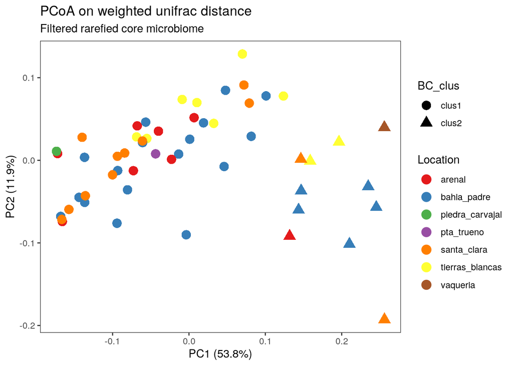

```r
# Extract the first 2 PCs
PCOAaxes <- PCoA_RC$vectors[,c(1,2)]
colnames(PCOAaxes) = c("AxisWU_1", "AxisWU_2")

# Add to metadata
cbind(core.meta, PCOAaxes) -> core.meta

#plot
ggplot(core.meta,
       aes(AxisWU_1,
           AxisWU_2,
           color = Location,
           fill = Location,
           shape = BC_clus)) +
  geom_point(size = 4) +
  scale_colour_brewer(palette = "Set1") +
  theme_bw() +
  xlab("PC1 (53.8%)") +
  ylab("PC2 (11.9%)") +
  labs(title = "PCoA on weighted unifrac distance",
       subtitle = "Filtered rarefied core microbiome") +
  theme(panel.grid.major = element_blank(),
        panel.grid.minor = element_blank())
```

```r
detach("package:rbiom", unload = TRUE)
```

When using the core data set a similar and slightly stronger signal can be identified. As before, the final plot will be constructed using the a new cluster variable.

## 1.2 Clusters exploration

- Load metadata  
  *Note: using non-rarefied data*

```r
# Filtered non-rarefied ASV_tax relative abundance
# Data in proportions
read.csv("ASV_taxcomp.csv",
         row.names = 1,
         check.names = FALSE) -> ASV_taxacomp
```

- Prepare data and table

```r
# Filtered phyla
dplyr::select(ASV_taxacomp,
              -"ASV",
              -"Kingdom",
              -"Family",
              -"Class",
              -"Genus",
              -"Order",
              -"Species") -> ASV_phyl

# Agregate to phyla
aggregate(ASV_phyl[1:54],
          by = list(ASV_phyl$Phylum),
          FUN = sum) -> ASV_phyl

# Add rownames
rownames(ASV_phyl) <- ASV_phyl[,1]

# Transpose
as.data.frame(t(ASV_phyl[,-1])) -> phyl

# Get clusters
# Cluster 1
# Get list
JFFS.meta %>%
  filter(BC_clus == "clus1") %>%
  droplevels() %>%
  pull(label) -> C1

# Filter
as.data.frame(t(phyl %>%
                  filter(rownames(phyl) %in% C1))) -> phyl1

# Summary
round(rowMeans(phyl1), 4)*100 -> phyl1$mean
round(apply(phyl1[,1:11], 1, sd), 4)*100 -> phyl1$SD

# Select columns and filter phyla with relative abundace > 1%
phyl1 %>%
  rownames_to_column("Phylum") %>%
  dplyr::select(Phylum, mean, SD) %>%
  filter(mean > 1) %>%
  mutate(Cluster = c(rep("clus1", 5))) -> phyl1


# Cluster 2
# Get list
JFFS.meta %>%
  filter(BC_clus == "clus2") %>%
  droplevels() %>%
  pull(label) -> C2

# Filter
as.data.frame(t(phyl %>%
                  filter(rownames(phyl) %in% C2))) -> phyl2

# Summary
round(rowMeans(phyl2), 4)*100 -> phyl2$mean
round(apply(phyl2[,1:11], 1, sd), 4)*100 -> phyl2$SD

# Select columns and filter phyla with relative abundace > 1%
phyl2 %>%
  rownames_to_column("Phylum") %>%
  dplyr::select(Phylum, mean, SD) %>%
  filter(mean > 1) %>%
  mutate(Cluster = c(rep("clus2", 5))) -> phyl2

# Combine tables
rbind(phyl1, phyl2) -> phyls
```

**Figure 10:** Comparison of relative abundance at the phylum level among clusters *In Manuscript: Figure 5*

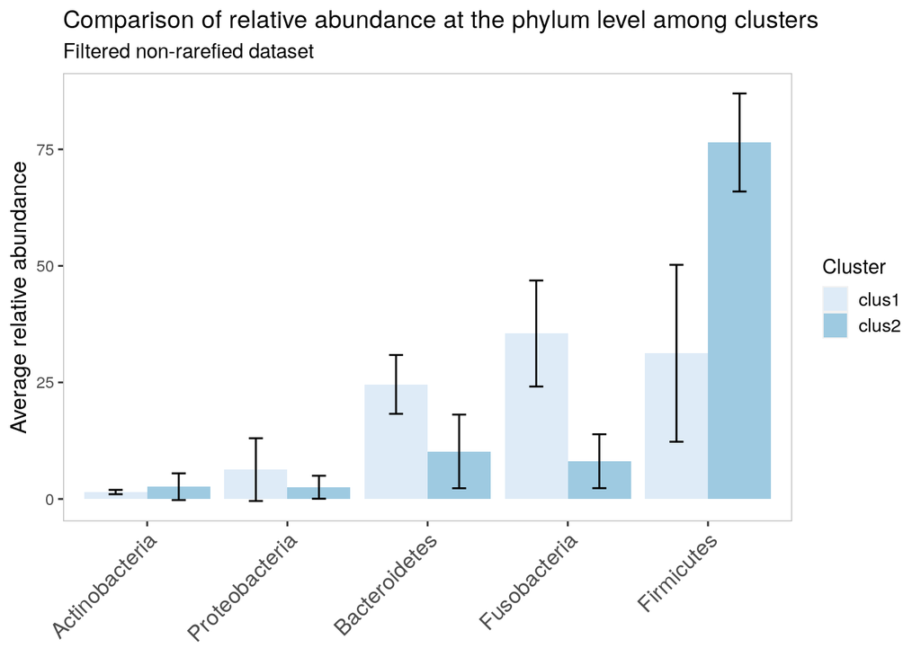

```r
phyls %>%
ggplot(aes(x=reorder(Phylum,
                     mean),
                       y = mean,
                       fill = Cluster)) +
  geom_bar(stat = "identity",
           position = position_dodge()) +
  geom_errorbar(aes(ymin = mean - SD,
                    ymax = mean + SD),
                width=.2,
                position=position_dodge(.9)) +
  scale_fill_brewer(palette = "Blues") +
  ylab("Average relative abundance") +
  theme(axis.title.x = element_blank(),
        panel.border = element_rect(colour = "grey",
                                    fill=NA),
        panel.background = element_blank(),
        axis.title.y = element_text(size=12),
        axis.text.x = element_text(angle = 45,
                                   hjust = 1,
                                   size = 12),
        legend.text = element_text(size = 10)) +
  guides(fill = guide_legend(keywidth = 1,
                                 keyheight = 1)) +
  labs(title = "Comparison of relative abundance at the phylum level among clusters",
       subtitle = "Filtered non-rarefied dataset")
```

The ordination analysis revealed a consistent clusterisation pattern. This plot compared the relative abundance between the two clusters at the phylum level. The differences between the two clusters are consistent even at this higher taxonomic level.

## 1.3. Hypothesis testing

Based on the previous results, the hypothesis that cluster 1 is different to cluster 2 will be tested  
### 1.3.1 Permutational Multivariate Analysis of Variance (PERMANOVA)  
Null hypothesis: There is no difference in either within or between group Bray-Curtis distance for any of the clusters  
-PERMANOVA using Bray-Curtis (filtered rarefied full dataset)

```r
set.seed(123)
adonis(as.matrix(dist_RF) ~ BC_clus,
       data = JFFS.meta,
       permutations = 999)
```

```
##
## Call:
## adonis(formula = as.matrix(dist_RF) ~ BC_clus, data = JFFS.meta,      permutations = 999)
##
## Permutation: free
## Number of permutations: 999
##
## Terms added sequentially (first to last)
##
##           Df SumsOfSqs MeanSqs F.Model      R2 Pr(>F)
## BC_clus    1    2.0195 2.01953  10.096 0.16259  0.001 ***
## Residuals 52   10.4017 0.20003         0.83741
## Total     53   12.4213                 1.00000
## ---
## Signif. codes:  0 '***' 0.001 '**' 0.01 '*' 0.05 '.' 0.1 ' ' 1
```

-PERMANOVA using Bray-Curtis (filtered rarefied core dataset)

```r
set.seed(123)
adonis(as.matrix(dist_RC) ~ BC_clus,
       data = core.meta,
       permutations = 999)
```

```
##
## Call:
## adonis(formula = as.matrix(dist_RC) ~ BC_clus, data = core.meta,      permutations = 999)
##
## Permutation: free
## Number of permutations: 999
##
## Terms added sequentially (first to last)
##
##           Df SumsOfSqs MeanSqs F.Model      R2 Pr(>F)
## BC_clus    1    2.1703 2.17035  13.636 0.20775  0.001 ***
## Residuals 52    8.2765 0.15916         0.79225
## Total     53   10.4468                 1.00000
## ---
## Signif. codes:  0 '***' 0.001 '**' 0.01 '*' 0.05 '.' 0.1 ' ' 1
```

# 5. SIMPER at the Genus level *Note. Using rarefied core data*

To explore how genera differ between clusters, SIMPER analysis will be use to calculate the contribution of each genus (%) to the dissimilarity between each two cluster.  
- load data *Note. Using rarefied core data*

```r
read.csv("tax_FR.csv",
         row.names = 1,
         check.names = FALSE) -> tax_RC
```

- Prepare data

```r
# Full data
# Combine taxa with ASV Table
# Trasform matrix to data fram
as.data.frame(t(ASV.RC)) -> ASVRC

as.data.frame(tax_RC) -> taxRC

# combine
merge(ASVRC,
      taxRC,
      by = "row.names") -> ASV_taxRC

# Select samples and genus columns
dplyr::select(ASV_taxRC,
              -"Row.names",
              -"Kingdom",
              -"Family",
              -"Class",
              -"Phylum",
              -"Order",
              -"Species") -> Gen_RC

# Agregate to Genus
aggregate(Gen_RC[1:54],
          by = list(Gen_RC$Genus),
          FUN = sum) -> ASV_Gen_RC

# Add row names
rownames(ASV_Gen_RC) <- ASV_Gen_RC$Group.1

# As matrix, simper needs samples as rows
as.matrix(t(ASV_Gen_RC[,-1])) -> Gen_Mat
```

## 5.1. Run SIMPER

```r
simper(Gen_Mat,
       core.meta$BC_clus,
       permutations = 999)
```

```
## cumulative contributions of most influential species:
##
## $clus2_clus1
##                Peptoclostridium                   Fusobacterium
##                       0.2460116                       0.4901221
##                     Bacteroides         Ruminococcaceae UCG-005
##                       0.5859594                       0.6488404
## [Ruminococcus] gauvreauii group
##                       0.7015811
```

Five Genera contributed to 70% of the variation between clusters. *Peptoclostridium* and *Fusobacterium* only, Contributed to almost 50% of this variation.

## 5.2 Hypothesis testing

- Preparing data

```r
# From matrix to dataframe
data.frame("label" = row.names(Gen_Mat),
           Gen_Mat) -> Gen_df

# Join
left_join(core.meta,
          Gen_df,
          by = ("rowname" = "label")) -> Gen_df

# Select Relevant columns. Be aware on some name modifications
Gen_df %>%
  select(label,
         BC_clus,
         Peptoclostridium,
         Fusobacterium,
         Bacteroides,
         Ruminococcaceae.UCG.005,
         X.Ruminococcus..gauvreauii.group) -> Gen_df
```

### 5.2.1 *Peptoclostridium*

- Visualisation **Figure 11:** Comparison of *Peptoclostridium* abundance among clusters. Filtered rarefied dataset

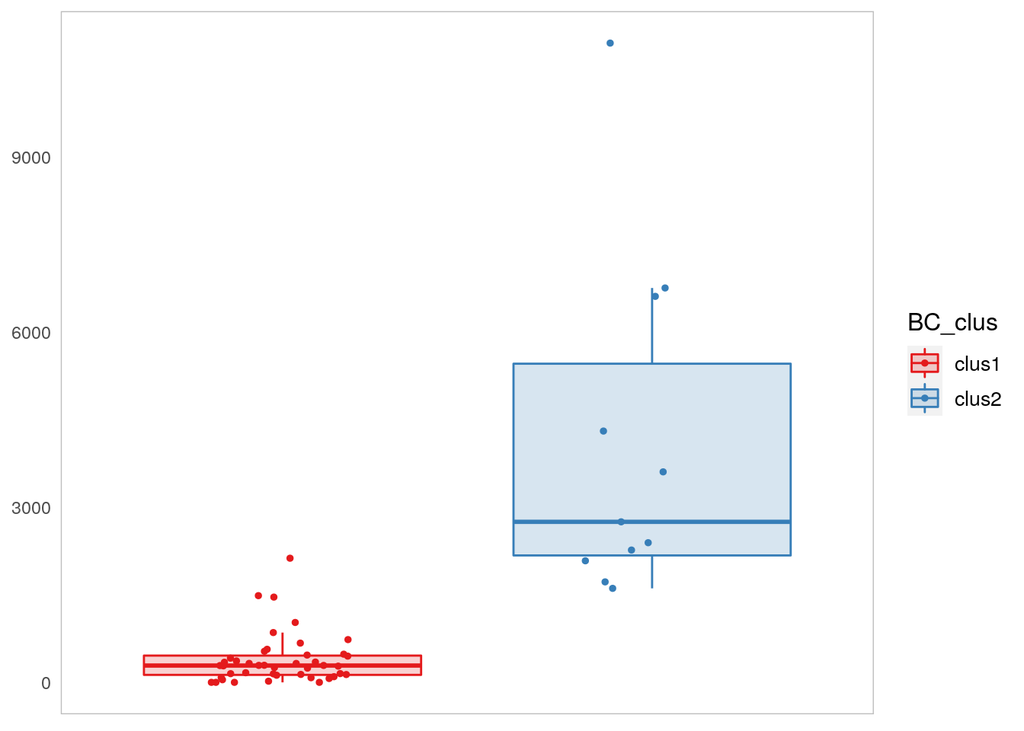

```r
Gen_df %>%
  ggplot(aes( x = BC_clus,
              y = Peptoclostridium,
              fill = BC_clus,
              colour= BC_clus)) +
  geom_boxplot(alpha = 0.2, outlier.shape = NA) +
  geom_jitter(height = 0,
              size = 1,
              width = 0.2) +
  theme(axis.text.x = element_blank(),
        axis.ticks = element_blank(),
        axis.title.x = element_blank(),
        axis.title.y = element_blank(),
        panel.border = element_rect(colour = "grey",
                                    fill=NA),
        panel.background = element_blank(),
        legend.title = element_text(size = 12),
        legend.text = element_text(size = 10)) +
  scale_fill_brewer(palette = "Set1") +
  scale_colour_brewer(palette = "Set1")
```

```r
wilcox.test(Peptoclostridium ~ BC_clus,
            data = Gen_df, conf.int = TRUE)
```

```
##
##  Wilcoxon rank sum test with continuity correction
##
## data:  Peptoclostridium by BC_clus
## W = 3, p-value = 5.582e-07
## alternative hypothesis: true location shift is not equal to 0
## 95 percent confidence interval:
##  -4160 -1924
## sample estimates:
## difference in location
##                  -2429
```

### 5.2.2 *Fusobacterium*

**Figure 12:** Comparison of *Fusobacterium* abundance among clusters. Filtered rarefied core dataset

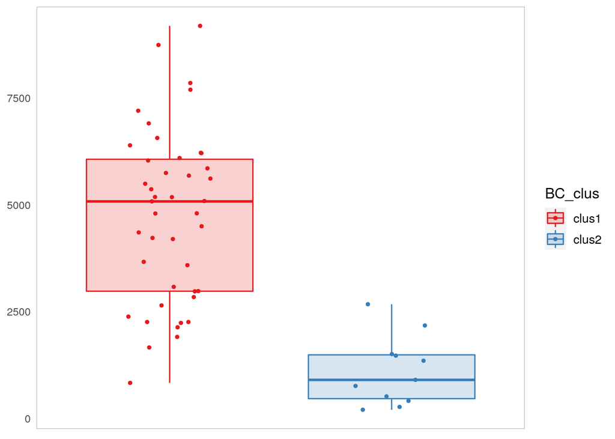

```r
Gen_df %>%
  ggplot(aes( x = BC_clus,
              y = Fusobacterium,
              fill = BC_clus,
              colour= BC_clus)) +
  geom_boxplot(alpha = 0.2, outlier.shape = NA) +
  geom_jitter(height = 0,
              size = 1,
              width = 0.2) +
  theme(axis.text.x = element_blank(),
        axis.ticks = element_blank(),
        axis.title.x = element_blank(),
        axis.title.y = element_blank(),
        panel.border = element_rect(colour = "grey",
                                    fill=NA),
        panel.background = element_blank(),
        legend.title = element_text(size = 12),
        legend.text = element_text(size = 10)) +
  scale_fill_brewer(palette = "Set1") +
  scale_colour_brewer(palette = "Set1")
```

```r
wilcox.test(Fusobacterium ~ BC_clus,
            data = Gen_df, conf.int = TRUE)
```

```
##
##  Wilcoxon rank sum test with continuity correction
##
## data:  Fusobacterium by BC_clus
## W = 456, p-value = 2.556e-06
## alternative hypothesis: true location shift is not equal to 0
## 95 percent confidence interval:
##  2322 4809
## sample estimates:
## difference in location
##                   3718
```

### 5.2.3. *Bacteroides*

**Figure 13:** Comparison of *Bacteroides* abundance among clusters. Filtered rarefied core dataset

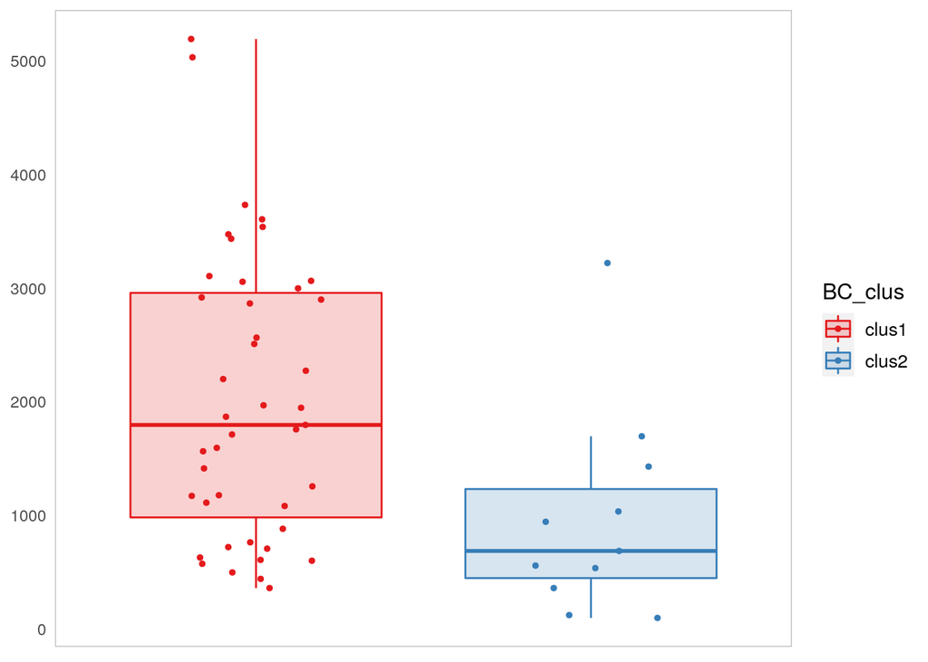

```r
Gen_df %>%
  ggplot(aes( x = BC_clus,
              y = Bacteroides,
              fill = BC_clus,
              colour= BC_clus)) +
  geom_boxplot(alpha = 0.2, outlier.shape = NA) +
  geom_jitter(height = 0,
              size = 1,
              width = 0.2) +
  theme(axis.text.x = element_blank(),
        axis.ticks = element_blank(),
        axis.title.x = element_blank(),
        axis.title.y = element_blank(),
        panel.border = element_rect(colour = "grey",
                                    fill=NA),
        panel.background = element_blank(),
        legend.title = element_text(size = 12),
        legend.text = element_text(size = 10)) +
  scale_fill_brewer(palette = "Set1") +
  scale_colour_brewer(palette = "Set1")
```

```r
wilcox.test(Bacteroides ~ BC_clus,
            data = Gen_df, conf.int = TRUE)
```

```
##
##  Wilcoxon rank sum test with continuity correction
##
## data:  Bacteroides by BC_clus
## W = 365.5, p-value = 0.005782
## alternative hypothesis: true location shift is not equal to 0
## 95 percent confidence interval:
##   234.0001 1832.0000
## sample estimates:
## difference in location
##                    961
```

### 5.2.4 *Ruminococcaceae UCG-005*

**Figure 14:** Comparison of *Ruminococcaceae UCG-005* abundance among clusters. Filtered rarefied core dataset

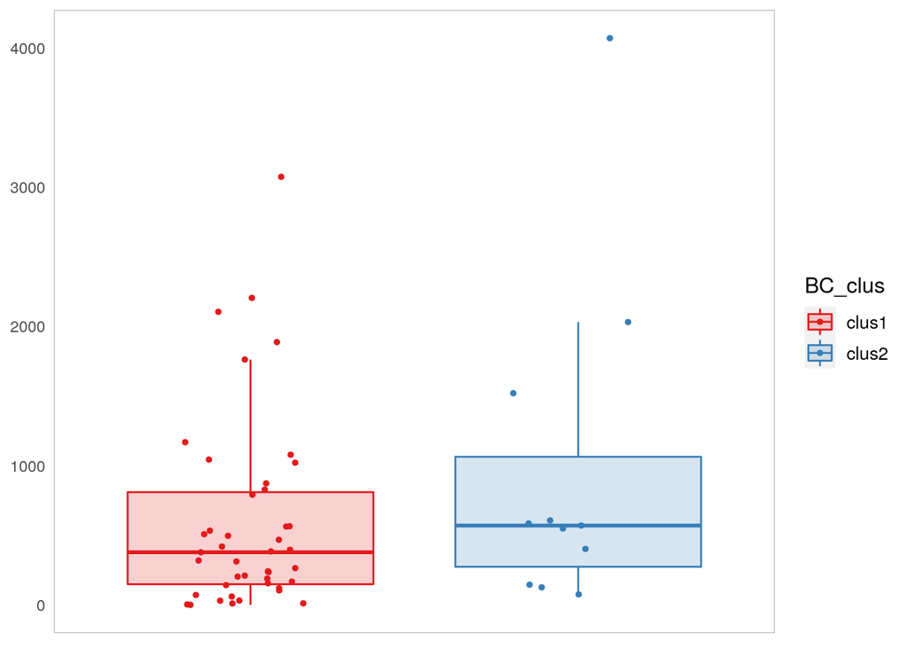

```r
Gen_df %>%
  ggplot(aes( x = BC_clus,
              y = Ruminococcaceae.UCG.005,
              fill = BC_clus,
              colour= BC_clus)) +
  geom_boxplot(alpha = 0.2, outlier.shape = NA) +
  geom_jitter(height = 0,
              size = 1,
              width = 0.2) +
  theme(axis.text.x = element_blank(),
        axis.ticks = element_blank(),
        axis.title.x = element_blank(),
        axis.title.y = element_blank(),
        panel.border = element_rect(colour = "grey",
                                    fill=NA),
        panel.background = element_blank(),
        legend.title = element_text(size = 12),
        legend.text = element_text(size = 10)) +
  scale_fill_brewer(palette = "Set1") +
  scale_colour_brewer(palette = "Set1")
```

```r
wilcox.test(Ruminococcaceae.UCG.005 ~ BC_clus,
            data = Gen_df, conf.int = TRUE)
```

```
##
##  Wilcoxon rank sum test
##
## data:  Ruminococcaceae.UCG.005 by BC_clus
## W = 177, p-value = 0.2083
## alternative hypothesis: true location shift is not equal to 0
## 95 percent confidence interval:
##  -499  135
## sample estimates:
## difference in location
##                   -151
```

### 5.2.5 *[Ruminococcus] gauvreauii group*

**Figure 15:** Comparison of *[Ruminococcus] gauvreauii group* abundance among clusters. Filtered rarefied core dataset

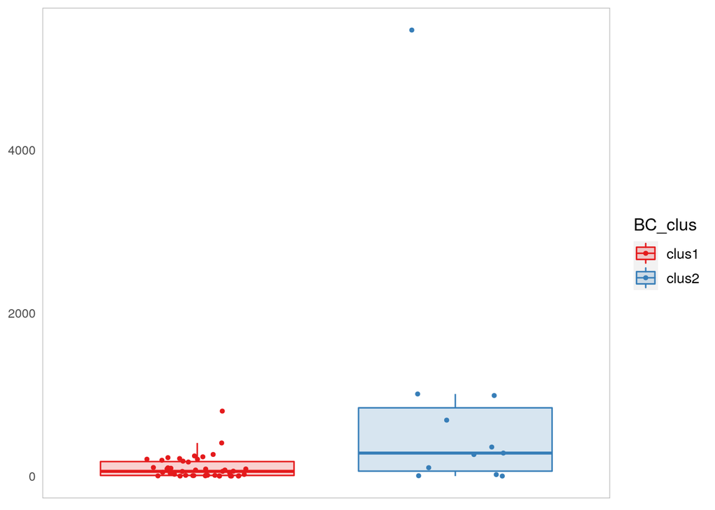

```r
Gen_df %>%
  ggplot(aes( x = BC_clus,
              y = X.Ruminococcus..gauvreauii.group,
              fill = BC_clus,
              colour= BC_clus)) +
  geom_boxplot(alpha = 0.2, outlier.shape = NA) +
  geom_jitter(height = 0,
              size = 1,
              width = 0.2) +
  theme(axis.text.x = element_blank(),
        axis.ticks = element_blank(),
        axis.title.x = element_blank(),
        axis.title.y = element_blank(),
        panel.border = element_rect(colour = "grey",
                                    fill=NA),
        panel.background = element_blank(),
        legend.title = element_text(size = 12),
        legend.text = element_text(size = 10)) +
  scale_fill_brewer(palette = "Set1") +
  scale_colour_brewer(palette = "Set1")
```

```r
wilcox.test(X.Ruminococcus..gauvreauii.group ~ BC_clus,
            data = Gen_df, conf.int = TRUE)
```

```
##
##  Wilcoxon rank sum test with continuity correction
##
## data:  X.Ruminococcus..gauvreauii.group by BC_clus
## W = 124, p-value = 0.0161
## alternative hypothesis: true location shift is not equal to 0
## 95 percent confidence interval:
##  -640.99999  -15.00003
## sample estimates:
## difference in location
##                   -237
```

# 6. Correlation Analysis *Using core data*

- Load necessary libraries

```r
library(Hmisc)
library(corrplot)
```

- Prepare data

```r
# Add the first two components of both ordination analysis
cbind2(Gen_Mat,
       as.matrix(core.meta[,c(9,10,12,13)])) -> Gen_Mat
```

- Prepare data

```r
rcorr(Gen_Mat,
      type = "spearman") -> Genus.corr
```

- Correlation table

```r
#add funtion to easily visualise the table
# ++++++++++++++++++++++++++++
# flattenCorrMatrix
# ++++++++++++++++++++++++++++
# cormat : matrix of the correlation coefficients
# pmat : matrix of the correlation p-values
flattenCorrMatrix <- function(cormat, pmat) {
  ut <- upper.tri(cormat)
  data.frame(
    row = rownames(cormat)[row(cormat)[ut]],
    column = rownames(cormat)[col(cormat)[ut]],
    cor  =(cormat)[ut],
    p = pmat[ut]
  )
}
flattenCorrMatrix(Genus.corr$r,
                  Genus.corr$P) -> corrtable

# Print scrollable table
kbl(corrtable, row.names = TRUE) %>%
  kable_paper() %>%
  scroll_box(width = "100%", height = "400px")
```

|  | row | column | cor | p |
| --- | --- | --- | --- | --- |
| 1 | [Eubacterium] coprostanoligenes group | [Ruminococcus] gauvreauii group | 0.3060674 | 0.0243972 |
| 2 | [Eubacterium] coprostanoligenes group | Alistipes | 0.1908869 | 0.1667704 |
| 3 | [Ruminococcus] gauvreauii group | Alistipes | -0.0110798 | 0.9366218 |
| 4 | [Eubacterium] coprostanoligenes group | Alloprevotella | -0.2702157 | 0.0481389 |
| 5 | [Ruminococcus] gauvreauii group | Alloprevotella | 0.2151691 | 0.1181630 |
| 6 | Alistipes | Alloprevotella | -0.0013549 | 0.9922419 |
| 7 | [Eubacterium] coprostanoligenes group | Bacteroides | -0.1427596 | 0.3031022 |
| 8 | [Ruminococcus] gauvreauii group | Bacteroides | -0.1969758 | 0.1533981 |
| 9 | Alistipes | Bacteroides | 0.0119322 | 0.9317567 |
| 10 | Alloprevotella | Bacteroides | -0.0315240 | 0.8209770 |
| 11 | [Eubacterium] coprostanoligenes group | Blautia | -0.0779739 | 0.5751824 |
| 12 | [Ruminococcus] gauvreauii group | Blautia | 0.2124847 | 0.1229337 |
| 13 | Alistipes | Blautia | -0.0460421 | 0.7409485 |
| 14 | Alloprevotella | Blautia | -0.0552139 | 0.6917019 |
| 15 | Bacteroides | Blautia | -0.3184513 | 0.0189338 |
| 16 | [Eubacterium] coprostanoligenes group | Butyricicoccus | 0.0649536 | 0.6407613 |
| 17 | [Ruminococcus] gauvreauii group | Butyricicoccus | -0.1426669 | 0.3034193 |
| 18 | Alistipes | Butyricicoccus | -0.1591010 | 0.2505025 |
| 19 | Alloprevotella | Butyricicoccus | -0.1517783 | 0.2732526 |
| 20 | Bacteroides | Butyricicoccus | 0.0622326 | 0.6548405 |
| 21 | Blautia | Butyricicoccus | -0.2386989 | 0.0821663 |
| 22 | [Eubacterium] coprostanoligenes group | Clostridium sensu stricto 2 | -0.2999172 | 0.0275695 |
| 23 | [Ruminococcus] gauvreauii group | Clostridium sensu stricto 2 | 0.0210304 | 0.8800214 |
| 24 | Alistipes | Clostridium sensu stricto 2 | -0.1069479 | 0.4414628 |
| 25 | Alloprevotella | Clostridium sensu stricto 2 | 0.1393780 | 0.3148168 |
| 26 | Bacteroides | Clostridium sensu stricto 2 | -0.0186124 | 0.8937314 |
| 27 | Blautia | Clostridium sensu stricto 2 | 0.4224115 | 0.0014636 |
| 28 | Butyricicoccus | Clostridium sensu stricto 2 | -0.1742717 | 0.2075483 |
| 29 | [Eubacterium] coprostanoligenes group | Collinsella | 0.1490365 | 0.2821130 |
| 30 | [Ruminococcus] gauvreauii group | Collinsella | 0.1625875 | 0.2401353 |

[output cut: 531 more lines]

```r
detach("package:Hmisc", unload = TRUE)
```

**Figure 16:** Spearman rank correlation correlogram between bacterial genera and the first two principal components generated from Unifraq and Bray-Curtis distances. Using core data. *In manuscript: Figure 6*

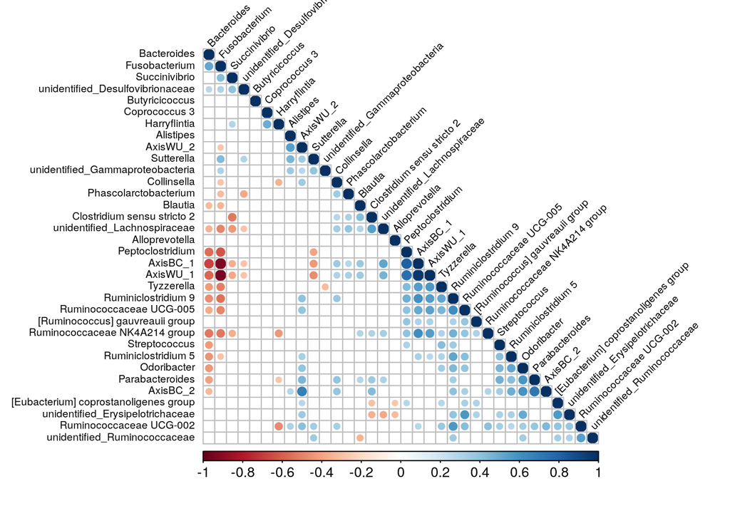

```r
corrplot(Genus.corr$r,
         tl.cex = 0.6,
         tl.col = "black",
         type = "lower",
         order = "hclust",
         p.mat = Genus.corr$P,
         sig.level = 0.05,
         insig = "blank",
         tl.srt = 45,
         cl.ratio = 0.1)
```